# TASK 02 : EXPLORATORY DATA ANALYSIS (EDA):-

## BY @CODTECH IT SOLUTION--->

**Start with a dataset of your choice and perform EDA using libraries like pandas, numpy,and matplotlib or seaborn. Explore the data's characteristics, distributions, correlations,and outliers. Visualize your findings with histograms, scatter plots, and heatmaps togain insights into the data.**

# PROJECT SUMMARY : Exploratary Data Analysis (EDA) with Iris Dataset

## Project Overview

**The Iris Dataset is a classic dataset widely used in data science and machine learning for testing algorithms and demonstrating data analysis techniques. Collected by British biologist and statistician Ronald A. Fisher in 1936, it comprises measurements of four features of iris flowers from three different species. The dataset is particularly valued for its simplicity, enabling clear demonstrations of data classification, clustering, and visualization techniques.**

## Objectives

- **Educational Tool:** *To serve as an introductory dataset for learning and teaching data science and machine learning concepts.*
- **Algorithm Testing:** *To provide a standard dataset for benchmarking and testing classification and clustering algorithms.*
- **Data Analysis:** *To enable detailed exploratory data analysis (EDA) and visualization techniques.*

## Key Features

- **Species:** *The dataset includes three species of iris flowers: Iris setosa, Iris versicolor, and Iris virginica.*
- **Measurements:** *Four features measured in centimeters for each flower:*
- Sepal length
- Sepal width
- Petal length
- Petal width
- **Instances:** *A total of 150 observations, with 50 samples from each species.*

## Data Description

*The dataset contains the following attributes:*

- **Sepal Length (cm):** *Continuous variable representing the length of the sepal.*
- **Sepal Width (cm):** *Continuous variable representing the width of the sepal.*
- **Petal Length (cm):** *Continuous variable representing the length of the petal.*
- **Petal Width (cm):** *Continuous variable representing the width of the petal.*
- **Species:** *Categorical variable representing the species of the iris flower (Iris setosa, Iris versicolor, Iris virginica).*

## Applications

- **Classification:** *The dataset is often used to train and test classification algorithms such as k-nearest neighbors (KNN), support vector machines (SVM), and decision trees.*
- **Clustering:** *It provides a basis for demonstrating clustering techniques like k-means clustering and hierarchical clustering.*
- **Visualization:** *The simplicity and structure of the dataset make it ideal for visualizing data distributions and relationships using scatter plots, histograms, and pair plots.*

## Expected Outcomes

- **Skill Development:** *Learners can develop and hone their skills in data preprocessing, analysis, and visualization.*
- **Algorithm Insights:** *Practitioners can gain insights into the performance and behavior of various machine learning algorithms.*
- **Benchmarking:** *esearchers can use the dataset to benchmark new algorithms against established ones.*

## Conclusion

**The Iris Dataset remains a cornerstone in the field of data science and machine learning education. Its straightforward nature and the clear distinctions between its classes make it an excellent resource for both beginners and experienced practitioners to explore and understand fundamental concepts in data analysis, classification, and clustering.**

## **This Project is Created By Shahrukh Khan (Data Analyst/Business Analyst)**

### *Please visit my GitHub account for more info--(https://github.com/Shahrukhkhan1580)*

### *Visit my Linkedin account for more details about me--(www.linkedin.com/in/shahrukhkhaan)*

## Import the Required Libraries

```python
import pandas as pd
import numpy as np
import seaborn as sns
import matplotlib.pyplot as plt
from sklearn.datasets import load_iris
```

### Load the Iris dataset

```python
iris = load_iris()
iris_df = pd.DataFrame(data=iris.data, columns=iris.feature_names)
iris_df['species'] = iris.target
iris_df['species'] = iris_df['species'].map({0: 'setosa', 1: 'versicolor', 2: 'virginica'})
```

#### Display the first few rows of the dataset

```python
print(iris_df.head())
```

```
   sepal length (cm)  sepal width (cm)  petal length (cm)  petal width (cm)  \
0                5.1               3.5                1.4               0.2
1                4.9               3.0                1.4               0.2
2                4.7               3.2                1.3               0.2
3                4.6               3.1                1.5               0.2
4                5.0               3.6                1.4               0.2

  species
0  setosa
1  setosa
2  setosa
3  setosa
4  setosa
```

## Data Preprocessing

**Check Null Values or Missing Values**

```python
iris_df.isnull().sum()
```

```
sepal length (cm)    0
sepal width (cm)     0
petal length (cm)    0
petal width (cm)     0
species              0
dtype: int64
```

```python
iris_df.dtypes
```

```
sepal length (cm)    float64
sepal width (cm)     float64
petal length (cm)    float64
petal width (cm)     float64
species               object
dtype: object
```

```python
iris_df.columns
```

```
Index(['sepal length (cm)', 'sepal width (cm)', 'petal length (cm)',
       'petal width (cm)', 'species'],
      dtype='object')
```

# Exploratary Data Analysis (EDA)

## Basic Characteristics

```python
iris_df.describe()
```

|  | sepal length (cm) | sepal width (cm) | petal length (cm) | petal width (cm) |
| --- | --- | --- | --- | --- |
| count | 150.000000 | 150.000000 | 150.000000 | 150.000000 |
| mean | 5.843333 | 3.057333 | 3.758000 | 1.199333 |
| std | 0.828066 | 0.435866 | 1.765298 | 0.762238 |
| min | 4.300000 | 2.000000 | 1.000000 | 0.100000 |
| 25% | 5.100000 | 2.800000 | 1.600000 | 0.300000 |
| 50% | 5.800000 | 3.000000 | 4.350000 | 1.300000 |
| 75% | 6.400000 | 3.300000 | 5.100000 | 1.800000 |
| max | 7.900000 | 4.400000 | 6.900000 | 2.500000 |

## Distribution of Iris Data set

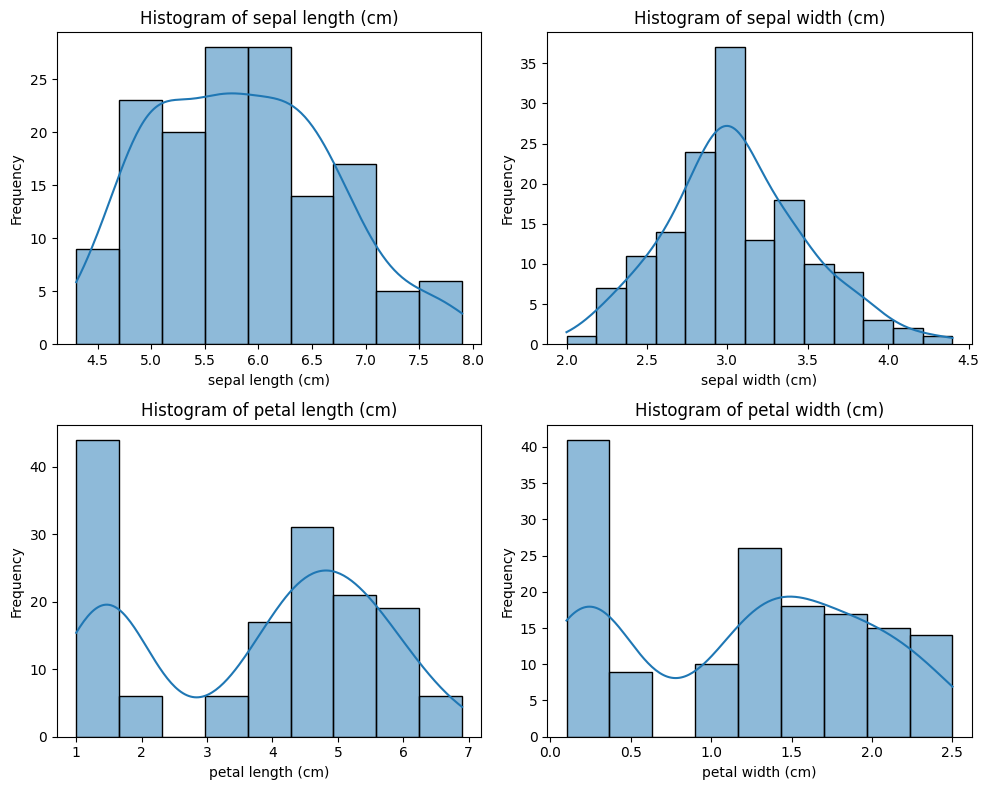

```python
plt.figure(figsize=(10, 8))
for i, feature in enumerate(iris_df.columns[:-1]):
    plt.subplot(2, 2, i + 1)
    sns.histplot(iris_df[feature], kde=True)
    plt.title(f'Histogram of {feature}')
    plt.xlabel(feature)
    plt.ylabel('Frequency')
plt.tight_layout()
plt.show()
```

## Pairplot to visualize relationships between variables

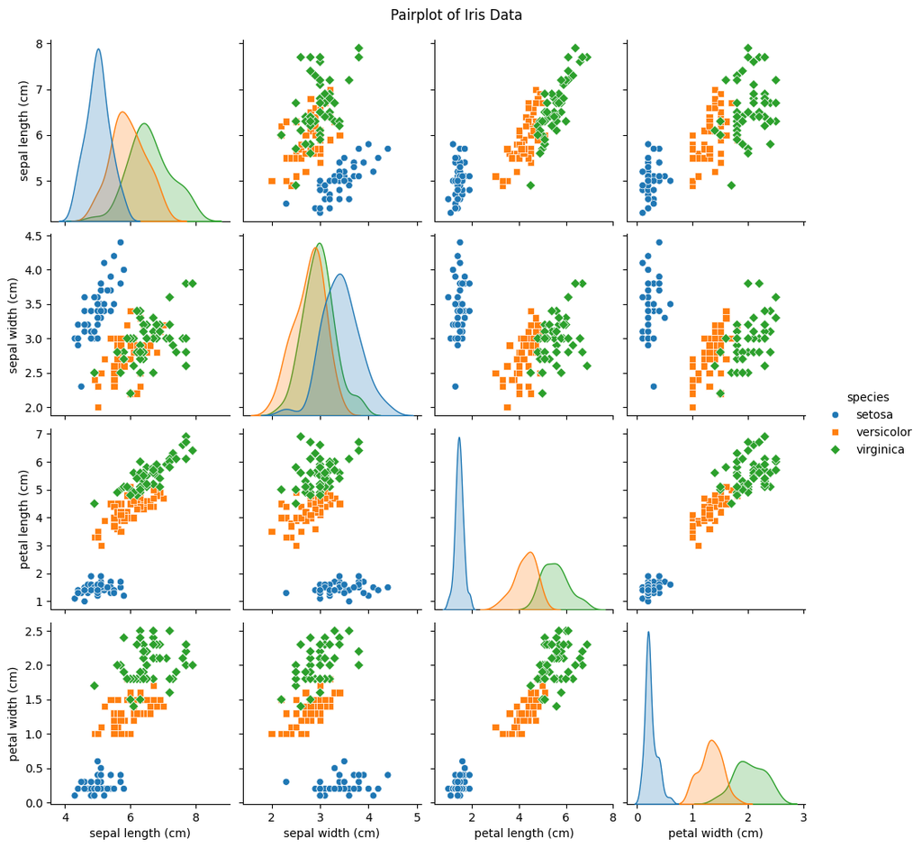

```python
sns.pairplot(iris_df, hue='species', markers=["o", "s", "D"])#marker is defined the shape
plt.suptitle("Pairplot of Iris Data", y=1.02)
plt.show()
```

## Lets Find the Outliers:

- **To find outliers in the Iris dataset, we need to perform several steps, including loading the dataset, exploring its structure, and applying statistical techniques to identify outliers.**
- **We use methods like the IQR (Interquartile Range) Or Z-score to identify outliers.**

```python
# redefine the loaded data
iris_df = pd.DataFrame(data=iris.data, columns=iris.feature_names)
# Calculate Q1 (25th percentile) and Q3 (75th percentile) for each feature
Q1 = iris_df.quantile(0.25)
Q3 = iris_df.quantile(0.75)

# Calculate IQR (Interquartile Range)
IQR = Q3 - Q1

# Determine the lower and upper bounds for outliers
lower_bound = Q1 - (1.5 * IQR)
upper_bound = Q3 + (1.5 * IQR)

# Find outliers
outliers = ((iris_df < lower_bound) | (iris_df > upper_bound))

# Display the outliers
outlier_values = iris_df[outliers.any(axis=1)]
print(outlier_values)
```

```
    sepal length (cm)  sepal width (cm)  petal length (cm)  petal width (cm)
15                5.7               4.4                1.5               0.4
32                5.2               4.1                1.5               0.1
33                5.5               4.2                1.4               0.2
60                5.0               2.0                3.5               1.0
```

## We have identified the outliers in the Iris dataset using the IQR method. Here are the outlier values:

##### Index 15:

- Sepal length: 5.7 cm
- Sepal width: 4.4 cm
- Petal length: 1.5 cm
- Petal width: 0.4 cm

##### Index 32:

- Sepal length: 5.2 cm
- Sepal width: 4.1 cm
- Petal length: 1.5 cm
- Petal width: 0.1 cm

##### Index 33:

- Sepal length: 5.5 cm
- Sepal width: 4.2 cm
- Petal length: 1.4 cm
- Petal width: 0.2 cm

##### Index 60:

- Sepal length: 5.0 cm
- Sepal width: 2.0 cm
- Petal length: 3.5 cm
- Petal width: 1.0 cm

**These points fall outside the typical range for their respective features, making them potential outliers**

#### Boxplot to visualize the outliers and distribution of features

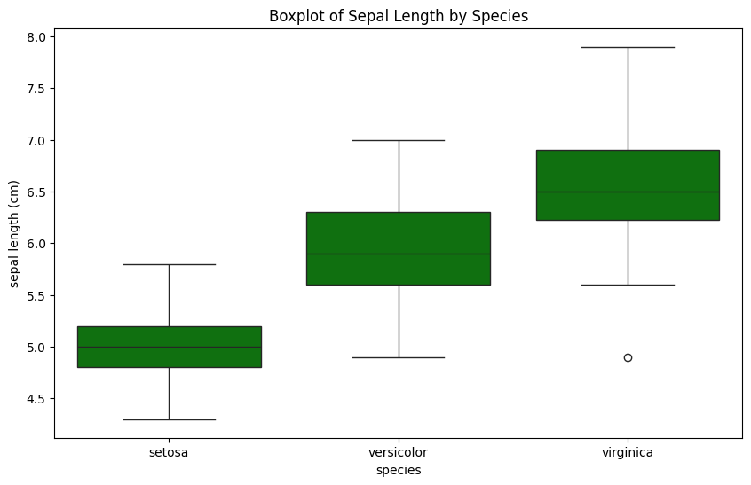

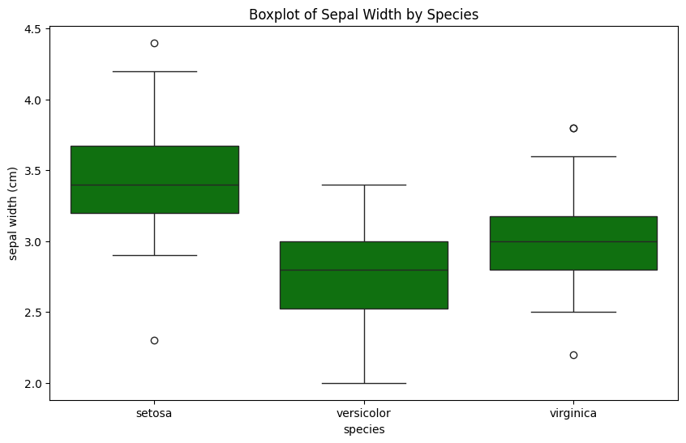

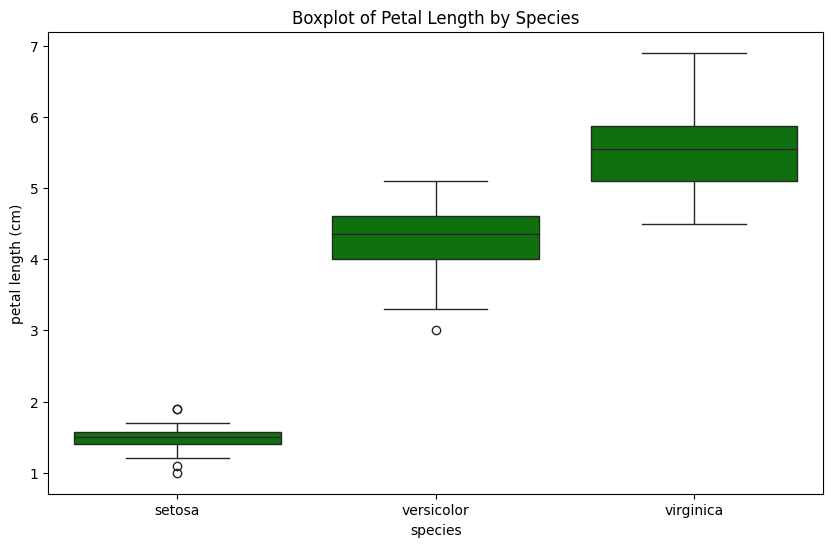

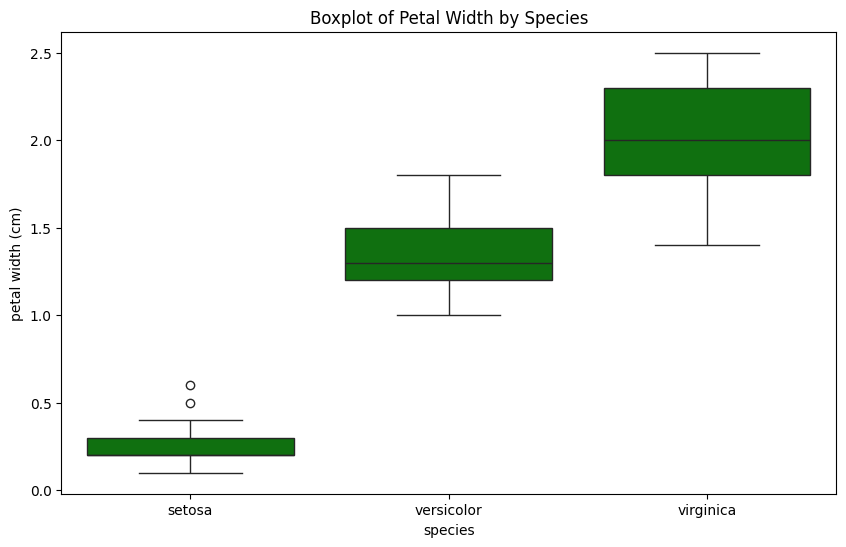

```python
# again load the data for boxplot
iris = load_iris()
iris_df = pd.DataFrame(data=iris.data, columns=iris.feature_names)
iris_df['species'] = iris.target
iris_df['species'] = iris_df['species'].map({0: 'setosa', 1: 'versicolor', 2: 'virginica'})


plt.figure(figsize=(10, 6))
sns.boxplot(x='species', y='sepal length (cm)', data=iris_df,color='green',)
plt.title("Boxplot of Sepal Length by Species")
plt.show()


plt.figure(figsize=(10, 6))
sns.boxplot(x='species', y='sepal width (cm)', data=iris_df,color='green')
plt.title("Boxplot of Sepal Width by Species")
plt.show()


plt.figure(figsize=(10, 6))
sns.boxplot(x='species', y='petal length (cm)', data=iris_df,color='green')
plt.title("Boxplot of Petal Length by Species")
plt.show()


plt.figure(figsize=(10, 6))
sns.boxplot(x='species', y='petal width (cm)', data=iris_df,color='green')
plt.title("Boxplot of Petal Width by Species")
plt.show()
```

## Correlation Matrix

**Remove the 'Species Column' for finding the Correlation and heatmap visualization and create new Datasset**

```python
Iris_data=iris_df[['petal length (cm)','petal width (cm)','sepal length (cm)','sepal width (cm)']]
```

```python
Iris_data
```

|  | petal length (cm) | petal width (cm) | sepal length (cm) | sepal width (cm) |
| --- | --- | --- | --- | --- |
| 0 | 1.4 | 0.2 | 5.1 | 3.5 |
| 1 | 1.4 | 0.2 | 4.9 | 3.0 |
| 2 | 1.3 | 0.2 | 4.7 | 3.2 |
| 3 | 1.5 | 0.2 | 4.6 | 3.1 |
| 4 | 1.4 | 0.2 | 5.0 | 3.6 |
| ... | ... | ... | ... | ... |
| 145 | 5.2 | 2.3 | 6.7 | 3.0 |
| 146 | 5.0 | 1.9 | 6.3 | 2.5 |
| 147 | 5.2 | 2.0 | 6.5 | 3.0 |
| 148 | 5.4 | 2.3 | 6.2 | 3.4 |
| 149 | 5.1 | 1.8 | 5.9 | 3.0 |

150 rows × 4 columns

### Correlagion with variables

```python
corr_matrix = Iris_data.corr()
print(corr_matrix)
```

```
                   petal length (cm)  petal width (cm)  sepal length (cm)  \
petal length (cm)           1.000000          0.962865           0.871754
petal width (cm)            0.962865          1.000000           0.817941
sepal length (cm)           0.871754          0.817941           1.000000
sepal width (cm)           -0.428440         -0.366126          -0.117570

                   sepal width (cm)
petal length (cm)         -0.428440
petal width (cm)          -0.366126
sepal length (cm)         -0.117570
sepal width (cm)           1.000000
```

## Heatmap of the correlation matrix

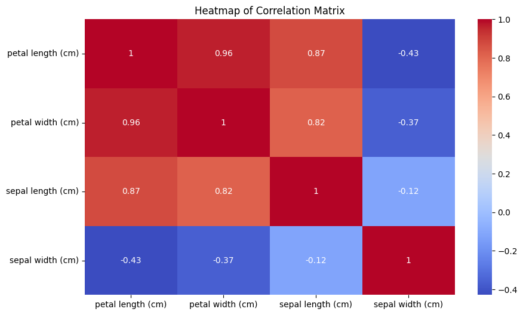

```python
plt.figure(figsize=(10, 6))
sns.heatmap(corr_matrix, annot=True, cmap='coolwarm')
plt.title("Heatmap of Correlation Matrix")
plt.show()
```

## Scatter Plot using Matplolib

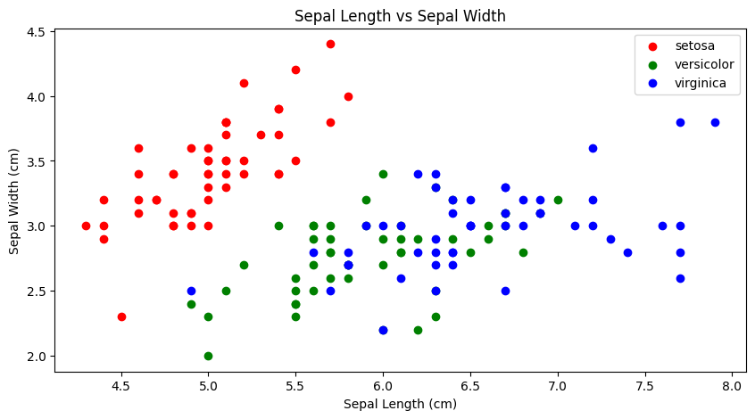

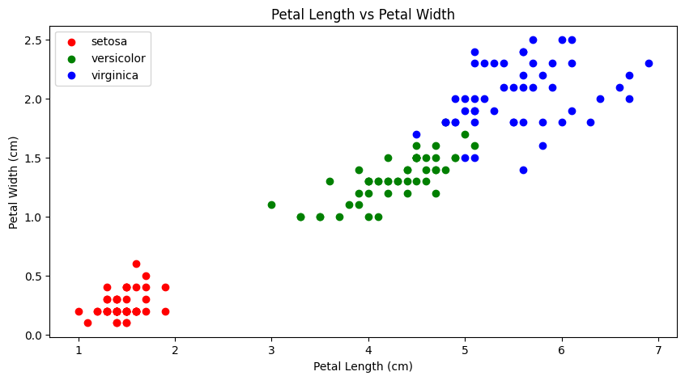

```python
# Scatter plot for Sepal length vs Sepal width
plt.figure(figsize=(10, 5))
colors = {'setosa': 'red', 'versicolor': 'green', 'virginica': 'blue'}
for species, color in colors.items():
    subset = iris_df[iris_df['species'] == species]
    plt.scatter(subset['sepal length (cm)'], subset['sepal width (cm)'], label=species, color=color)
plt.xlabel('Sepal Length (cm)')
plt.ylabel('Sepal Width (cm)')
plt.title('Sepal Length vs Sepal Width')
plt.legend()
plt.show()

# Scatter plot for Petal length vs Petal width
plt.figure(figsize=(10, 5))
for species, color in colors.items():
    subset = iris_df[iris_df['species'] == species]
    plt.scatter(subset['petal length (cm)'], subset['petal width (cm)'], label=species, color=color)
plt.xlabel('Petal Length (cm)')
plt.ylabel('Petal Width (cm)')
plt.title('Petal Length vs Petal Width')
plt.legend()
plt.show()
```

## Violin plot for better understanding of distribution and density

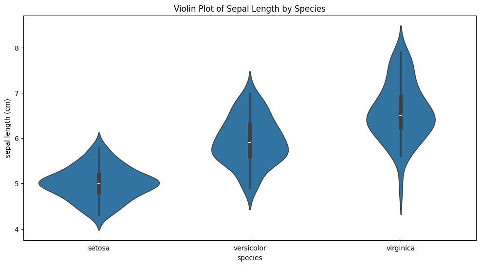

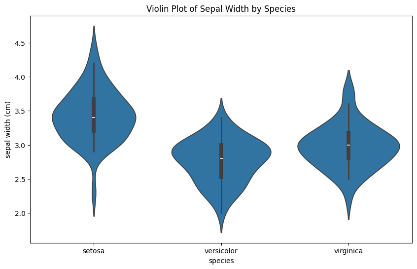

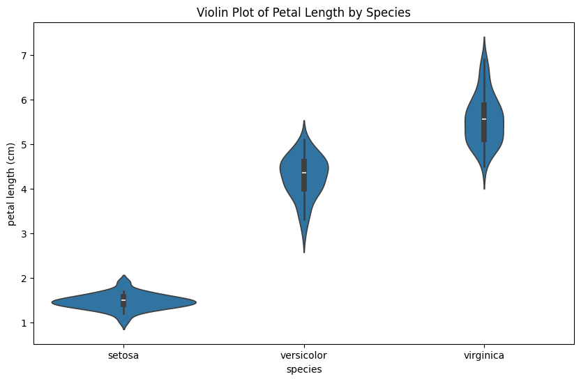

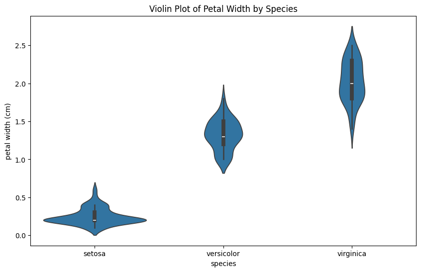

```python
plt.figure(figsize=(12, 6))
sns.violinplot(x='species', y='sepal length (cm)', data=iris_df)
plt.title("Violin Plot of Sepal Length by Species")
plt.show()

plt.figure(figsize=(10, 6))
sns.violinplot(x='species', y='sepal width (cm)', data=iris_df)
plt.title("Violin Plot of Sepal Width by Species")
plt.show()

plt.figure(figsize=(10, 6))
sns.violinplot(x='species', y='petal length (cm)', data=iris_df)
plt.title("Violin Plot of Petal Length by Species")
plt.show()

plt.figure(figsize=(10, 6))
sns.violinplot(x='species', y='petal width (cm)', data=iris_df)
plt.title("Violin Plot of Petal Width by Species")
plt.show()
```

# **Insights**

## **Insights from the Iris Dataset:**

### **4. Sepal width shows a weak correlation with other features, suggesting it might not be a strong predictor of species on its own.**

# **This Project is Created By Shahrukh Khan (Data Analyst/Business Analyst)**

## **Please visit my GitHub account for more info**--(https://github.com/Shahrukhkhan1580)

## **Visit my Linkedin account for more details about me**--(www.linkedin.com/in/shahrukhkhaan)